# Bellabeat

Assad Jawaid

2025-02-17

## Summary

Bellabeat, a health-focused company providing smart products would like to grow and improve their marketing strategy for the wellness tracker.

## Business Task

We have been tasked with analyzing smart device data and applying our insights to one of their products. For our analysis we will use Beallabeat’s Time product which tracks a users activity, sleep, and stress.

Stakeholders include Urška Sršen the Bellabeat co-founder and CCO (Chief Creative Officer) and Sando Mur also a Bellabeat co-founder and key member of Bellabeat executive team.

## Preparation

### Set Up

Spruce up the outputs

```r
library(kableExtra)
```

```r
library(tidyverse) # Cleaning data set
library(tidyr)
library(skimr)
library(janitor)
```

```r
library(corrplot)
library(ggplot2)
library(ggpubr)
library(VIM)
library(mice)
```

# Load data sets

```r
daily_activity <- read.csv("/Users/apple/GA Capstone/dailyActivity_merged.csv")
daily_steps <- read.csv("/Users/apple/GA Capstone/dailySteps_merged.csv")
sleep_days <- read.csv("/Users/apple/GA Capstone/sleepDay_merged.csv")
weight_log <- read.csv("/Users/apple/GA Capstone/weightLogInfo_merged.csv")
```

## Data insights

```r
kable(head(daily_activity))
```

| Id | ActivityDate | TotalSteps | TotalDistance | TrackerDistance | LoggedActivitiesDistance | VeryActiveDistance | ModeratelyActiveDistance | LightActiveDistance | SedentaryActiveDistance | VeryActiveMinutes | FairlyActiveMinutes | LightlyActiveMinutes | SedentaryMinutes | Calories |
| --- | --- | --- | --- | --- | --- | --- | --- | --- | --- | --- | --- | --- | --- | --- |
| 1503960366 | 4/12/2016 | 13162 | 8.50 | 8.50 | 0 | 1.88 | 0.55 | 6.06 | 0 | 25 | 13 | 328 | 728 | 1985 |
| 1503960366 | 4/13/2016 | 10735 | 6.97 | 6.97 | 0 | 1.57 | 0.69 | 4.71 | 0 | 21 | 19 | 217 | 776 | 1797 |
| 1503960366 | 4/14/2016 | 10460 | 6.74 | 6.74 | 0 | 2.44 | 0.40 | 3.91 | 0 | 30 | 11 | 181 | 1218 | 1776 |
| 1503960366 | 4/15/2016 | 9762 | 6.28 | 6.28 | 0 | 2.14 | 1.26 | 2.83 | 0 | 29 | 34 | 209 | 726 | 1745 |
| 1503960366 | 4/16/2016 | 12669 | 8.16 | 8.16 | 0 | 2.71 | 0.41 | 5.04 | 0 | 36 | 10 | 221 | 773 | 1863 |
| 1503960366 | 4/17/2016 | 9705 | 6.48 | 6.48 | 0 | 3.19 | 0.78 | 2.51 | 0 | 38 | 20 | 164 | 539 | 1728 |

```r
kable(head(daily_steps))
```

| Id | ActivityDay | StepTotal |
| --- | --- | --- |
| 1503960366 | 4/12/2016 | 13162 |
| 1503960366 | 4/13/2016 | 10735 |
| 1503960366 | 4/14/2016 | 10460 |
| 1503960366 | 4/15/2016 | 9762 |
| 1503960366 | 4/16/2016 | 12669 |
| 1503960366 | 4/17/2016 | 9705 |

```r
kable(head(sleep_days))
```

| Id | SleepDay | TotalSleepRecords | TotalMinutesAsleep | TotalTimeInBed |
| --- | --- | --- | --- | --- |
| 1503960366 | 4/12/2016 12:00:00 AM | 1 | 327 | 346 |
| 1503960366 | 4/13/2016 12:00:00 AM | 2 | 384 | 407 |
| 1503960366 | 4/15/2016 12:00:00 AM | 1 | 412 | 442 |
| 1503960366 | 4/16/2016 12:00:00 AM | 2 | 340 | 367 |
| 1503960366 | 4/17/2016 12:00:00 AM | 1 | 700 | 712 |
| 1503960366 | 4/19/2016 12:00:00 AM | 1 | 304 | 320 |

```r
kable(head(weight_log))
```

| Id | Date | WeightKg | WeightPounds | Fat | BMI | IsManualReport | LogId |
| --- | --- | --- | --- | --- | --- | --- | --- |
| 1503960366 | 5/2/2016 11:59:59 PM | 52.6 | 115.9631 | 22 | 22.65 | True | 1.462234e+12 |
| 1503960366 | 5/3/2016 11:59:59 PM | 52.6 | 115.9631 | NA | 22.65 | True | 1.462320e+12 |
| 1927972279 | 4/13/2016 1:08:52 AM | 133.5 | 294.3171 | NA | 47.54 | False | 1.460510e+12 |
| 2873212765 | 4/21/2016 11:59:59 PM | 56.7 | 125.0021 | NA | 21.45 | True | 1.461283e+12 |
| 2873212765 | 5/12/2016 11:59:59 PM | 57.3 | 126.3249 | NA | 21.69 | True | 1.463098e+12 |
| 4319703577 | 4/17/2016 11:59:59 PM | 72.4 | 159.6147 | 25 | 27.45 | True | 1.460938e+12 |

## Data formating

```r
# Make column names consistent
daily_activity <- clean_names(daily_activity)
daily_steps <-clean_names(daily_steps)
sleep_days <- clean_names(sleep_days)
weight_log <- clean_names(weight_log)

# Change date and time to datetime standard
daily_activity <- daily_activity %>%
  rename(date = activity_date) %>%
  mutate(date = as_date(date, format = "%m/%d/%Y"))

daily_steps <- daily_steps %>%
  rename(date = activity_day) %>%
  mutate(date = as_date(date, format = "%m/%d/%Y"))

sleep_days <- sleep_days %>%
  rename(date = sleep_day) %>%
  mutate(date = as.POSIXct(date, format = "%m/%d/%Y", tz=Sys.timezone()))

weight_log <- weight_log %>%
  rename(date = date) %>%
  mutate(date = as.POSIXct(date, format = "%m/%d/%Y %I:%M:%S %p", tz=Sys.timezone()))

# Add day of the week column for each data set
daily_activity$day_of_week <- wday(daily_activity$date, label = TRUE)
daily_steps$day_of_week <- wday(daily_steps$date, label = TRUE)
sleep_days$day_of_week <- wday(sleep_days$date, label = TRUE)
weight_log$day_of_week <- wday(weight_log$date, label = TRUE)

#Identify unique users and duplicates in data sets

### Unique users

n_distinct(daily_activity$id)
```

```
## [1] 33
```

```r
n_distinct(daily_steps$id)
```

```
## [1] 33
```

```r
n_distinct(sleep_days$id)
```

```
## [1] 24
```

```r
n_distinct(weight_log$id)
```

```
## [1] 8
```

```r
### Duplicates

sum(duplicated(daily_activity))
```

```
## [1] 0
```

```r
sum(duplicated(daily_steps))
```

```
## [1] 0
```

```r
sum(duplicated(sleep_days))
```

```
## [1] 3
```

```r
sum(duplicated(weight_log))
```

```
## [1] 0
```

```r
# Remove duplicates and NA in 'sleep_days' and other data sets
daily_activity <- daily_activity %>%
  distinct() %>%
  drop_na()

daily_steps <- daily_steps %>%
  distinct() %>%
  drop_na()

sleep_days <- sleep_days %>%
  distinct() %>%
  drop_na()
```

## Plotting daily activity data set

#### Find correlation and select columns with numerical data

```r
### Find correlation for 'daily_activity' with correlation plot
#### Select columns with numerical data
corrmatrices <- select(daily_activity, total_steps, total_distance, tracker_distance,
                       very_active_distance, moderately_active_distance, light_active_distance,
                       sedentary_active_distance, very_active_minutes, fairly_active_minutes,
                       lightly_active_minutes, sedentary_minutes, calories) %>%
  cor()
kable(head(round(corrmatrices,2)))
```

|  | total_steps | total_distance | tracker_distance | very_active_distance | moderately_active_distance | light_active_distance | sedentary_active_distance | very_active_minutes | fairly_active_minutes | lightly_active_minutes | sedentary_minutes | calories |
| --- | --- | --- | --- | --- | --- | --- | --- | --- | --- | --- | --- | --- |
| total_steps | 1.00 | 0.99 | 0.98 | 0.74 | 0.51 | 0.69 | 0.07 | 0.67 | 0.50 | 0.57 | -0.33 | 0.59 |
| total_distance | 0.99 | 1.00 | 1.00 | 0.79 | 0.47 | 0.66 | 0.08 | 0.68 | 0.46 | 0.52 | -0.29 | 0.64 |
| tracker_distance | 0.98 | 1.00 | 1.00 | 0.79 | 0.47 | 0.66 | 0.07 | 0.68 | 0.46 | 0.51 | -0.29 | 0.65 |
| very_active_distance | 0.74 | 0.79 | 0.79 | 1.00 | 0.19 | 0.16 | 0.05 | 0.83 | 0.21 | 0.06 | -0.06 | 0.49 |
| moderately_active_distance | 0.51 | 0.47 | 0.47 | 0.19 | 1.00 | 0.24 | 0.01 | 0.23 | 0.95 | 0.16 | -0.22 | 0.22 |
| light_active_distance | 0.69 | 0.66 | 0.66 | 0.16 | 0.24 | 1.00 | 0.10 | 0.15 | 0.22 | 0.89 | -0.41 | 0.47 |

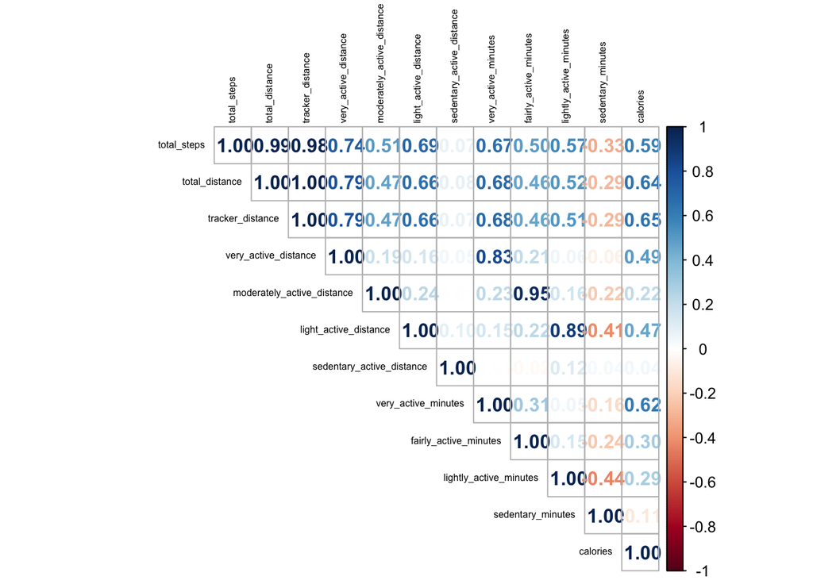

```r
corrplot(corrmatrices, method = "number", type = "upper", addCoef.col = "black", tl.col = "black",
         tl.srt = 90, tl.cex = 0.50)
```

### Plot using correlated columns

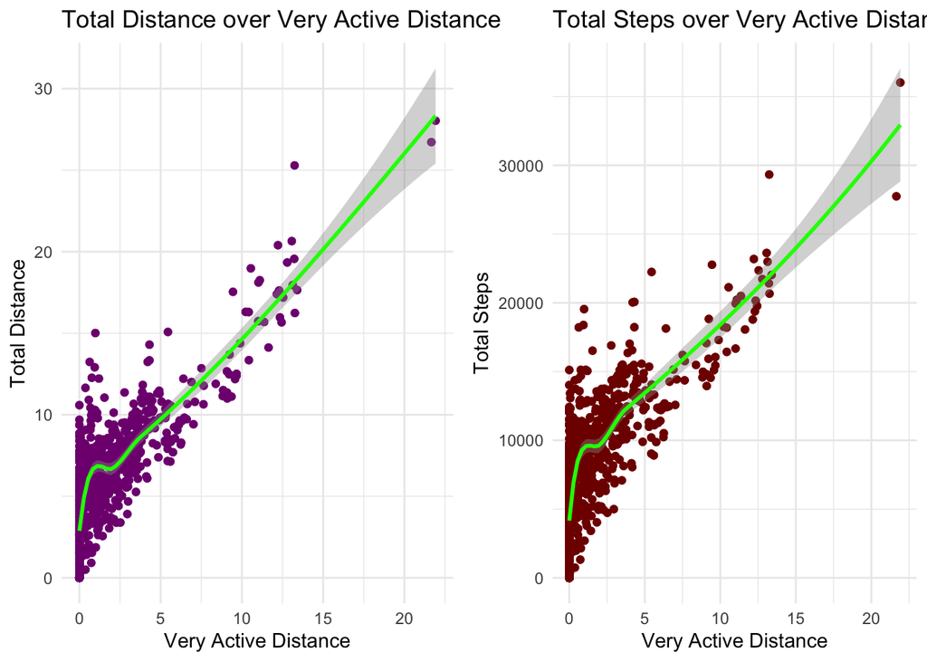

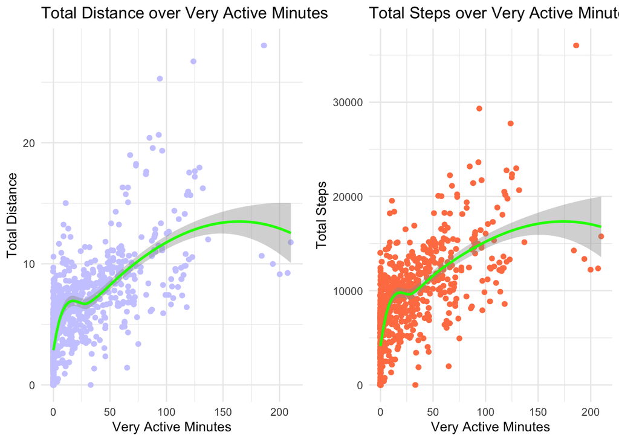

The curvature in the first set of scatter plots shows a positive correlation, however a very strong relation can be seen in the 0-5 range of Very Active Distance. We can assume that people who are very active naturally cover more ground or distance and have more steps.

The second set of scatter plots shows data points more concentrated in the 0-75 minute range indicating that most users have very active periods within this time frame. The confidence interval tells us that there is a margin of error surrounding the green line. In total, the plots indicate that being very active for a short time has a big impact on total distance and total steps.

### Analyze total distance and steps on a given day

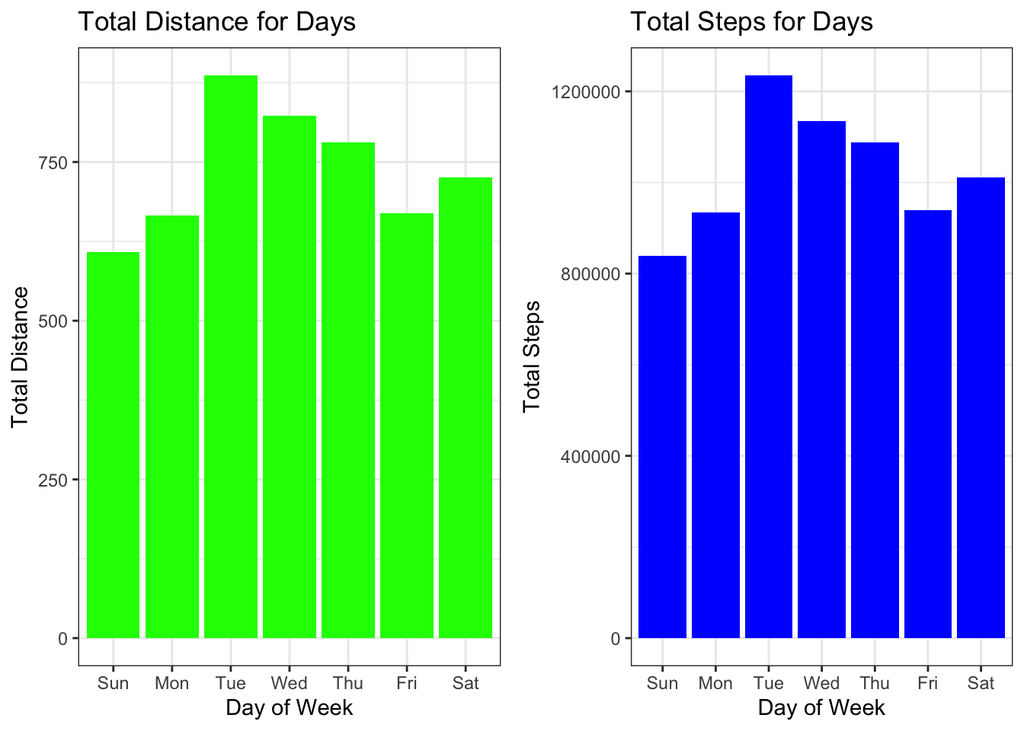

Both bar graphs show that there is a strong correlation between steps and distance. We can understand from these that users were most active on Tuesday and then became less active winding down to Friday. A spike occurs on Saturday possibly around the daytime leading to a quiet Sunday. We can summarize that weekdays tend to be more active than weekends.

#### Calculate y-intercept for sleep_days data set

```r
model <- lm(total_minutes_asleep~total_time_in_bed, data = sleep_days)
y_intercept <- coef(model)[1]
```

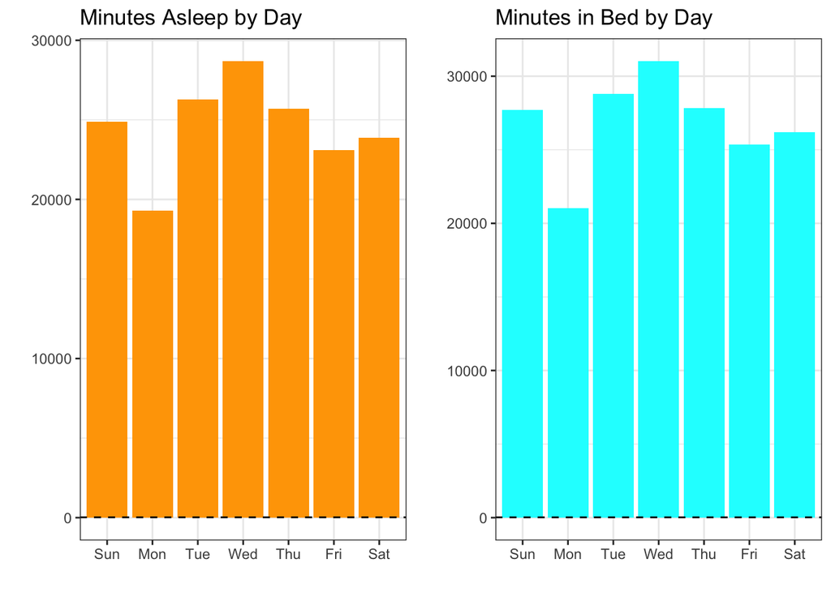

### Merge daily_activity, sleep_days, and weight_log for insights

```r
daily_sleep_weight <- merge(x=daily_activity, y=weight_log, by=c(
  "id", "date", "day_of_week"), all.x=TRUE, all.y=TRUE)
daily_sleep_weight <- merge(x=daily_sleep_weight, y=sleep_days, by=c(
  "id", "date", "day_of_week"), all.x=TRUE, all.y=TRUE)
```

### Check for NANs

```r
kable(colSums(is.na(daily_sleep_weight)))
```

|  | x |
| --- | --- |
| id | 0 |
| date | 0 |
| day_of_week | 0 |
| total_steps | 433 |
| total_distance | 433 |
| tracker_distance | 433 |
| logged_activities_distance | 433 |
| very_active_distance | 433 |
| moderately_active_distance | 433 |
| light_active_distance | 433 |
| sedentary_active_distance | 433 |
| very_active_minutes | 433 |
| fairly_active_minutes | 433 |
| lightly_active_minutes | 433 |
| sedentary_minutes | 433 |
| calories | 433 |
| weight_kg | 1306 |
| weight_pounds | 1306 |
| fat | 1371 |
| bmi | 1306 |
| is_manual_report | 1306 |
| log_id | 1306 |
| total_sleep_records | 963 |
| total_minutes_asleep | 963 |
| total_time_in_bed | 963 |

### Visualize NANs

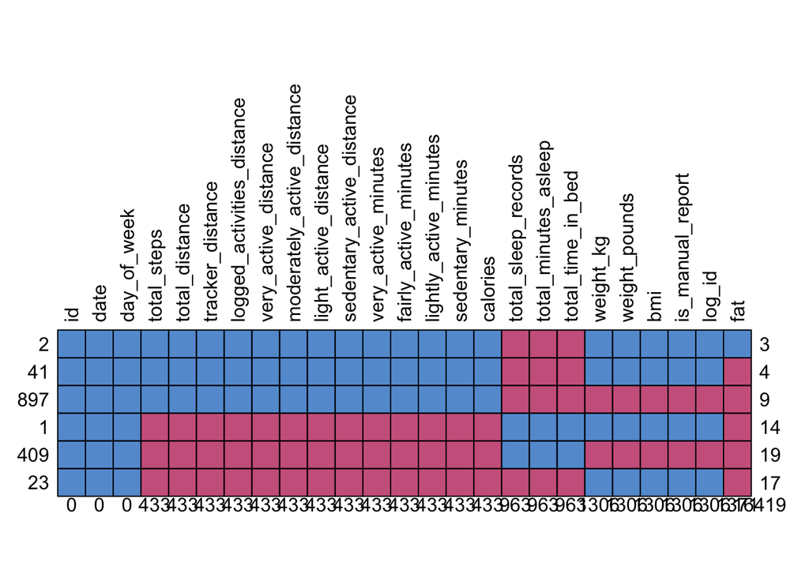

```r
nan_table <- md.pattern(daily_sleep_weight, plot = TRUE, rotate.names = TRUE)
```

### Use kNN to create impute value columns

```r
impute_columns <- c("total_steps", "total_distance", "tracker_distance",
                    "logged_activities_distance", "very_active_distance",
                    "moderately_active_distance", "light_active_distance",
                    "sedentary_active_distance", "very_active_minutes",
                    "fairly_active_minutes", "lightly_active_minutes", "sedentary_minutes",
                    "calories", "total_sleep_records", "total_minutes_asleep", "total_time_in_bed",
                    "weight_kg", "weight_pounds", "bmi", "is_manual_report", "log_id", "fat")
```

### Impute missing values from columns using kNN

```r
imputed_data <- kNN(daily_sleep_weight, variable = impute_columns)
```

### Plot graphs comparing weight to daily activities and sleeping time

[figure not shown]

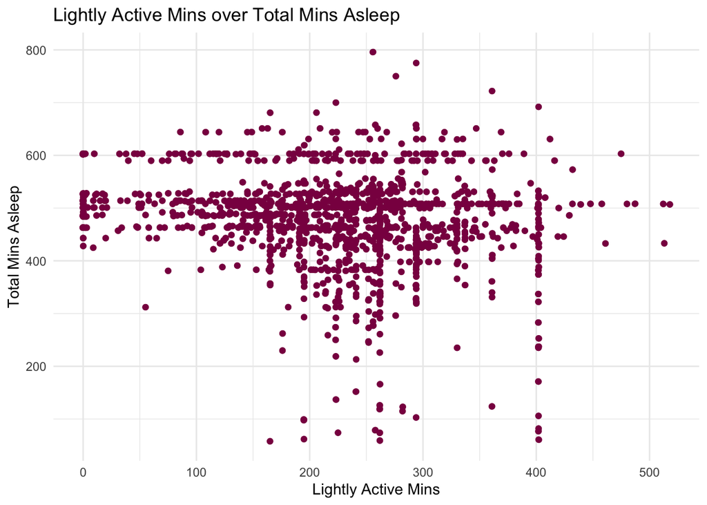

From the looks of it, the first scatter plot shows there is zero correlation between total time spent in bed and user’s weight. Even having imputed the missing values, zero relationship can be found in this data set.

The second scatter plot depicts a strong cluster between 400 to 600 minutes of sleep with most light activity minutes under 400 minutes. Overall, again the scatter plot shows us that both total minutes asleep and light active minutes are independent from one another.

## Summary and recommendations based on findings

Based on our analysis above and visualizations plotted, our insights uncovered that there were some high to medium correlations for total steps, total distance, very active minutes and distance, and lightly active minutes. This lead to other insights when combined with the sleep data set and categorizing by day.

Our recommendations are the following:

### Activity Levels

- Bellabeat implement a new feature that encourages users to maintain their activity levels during the middle of the week such as reminders to workout and increased weekend activity. Weak activity levels on Sunday gives Bellabeat an opportunity to improve this area and profit.

### Sleeping Consistency

- Bellabeat introduce games or scores showing sleep quality to maintain consistent sleep time and reduce time in bed.

### Very Active Minutes

- Bellabeat can benefit by putting prioritization on very active minutes. Because there is strong correlation for very active minutes and calorie in our correlation chart, Bellabeat can encourage and target users aiming for better weight management to focus more on intense activities such as running.